# Visualising timed transmission trees using epicontacts

2020-10-01

## Installation

This version of `epicontacts` is still in development but can be installed from github using the following command:

```r
remotes::install_github("reconhub/epicontacts@ttree")
library(epicontacts)
```

## Introduction

Visualising chains of transmission in an infectious disease outbreak can provide a useful overview of the situation and help guide interventions. This vignette illustrates how the `epicontacts` package can be used to create interactive transmission chain visualisations that display time on the x-axis, like the one below. Hover over the nodes for more information, drag the nodes to move them and click on them to highlight downstream cases.

[interactive chart not shown]

## Creating an epicontacts object

We begin with an `epicontacts` object, which consists of a linelist dataframe (specifying case IDs and any available case metadata) and a contacts dataframe (specifying pairs of IDs that have been in contact and any available properties of these contacts). For a detailed introduction to the `epicontacts` class, see the overview vignette.

For this vignette, we will use a simulated outbreak as an example dataset. The linelist dataframe contains anonymised case IDs, dates of symptom onset, age, sex and outcome for each case. The contacts dataframe specifies the infector and infectee in the `from` and `to` columns, as well as the contact status (suspected or confirmed), location of contact (community or hospital), duration of contact and date of first contact.

Below is an overview of the outbreak data as an `epicontacts` object.

```
##
## /// Epidemiological Contacts //
##
##   // class: epicontacts
##   // 41 cases in linelist; 41 contacts; directed
##
##   // linelist
##
## # A tibble: 41 x 5
##    id    onset      sex      age outcome
##    <chr> <date>     <fct>  <dbl> <fct>
##  1 iy4mz 2012-07-02 female  37.5 dead
##  2 3lg6z 2012-07-05 female  41.3 alive
##  3 01tkh 2012-07-05 male    15.6 unknown
##  4 2hydc 2012-07-10 female  42.2 alive
##  5 o4yid 2012-07-11 male    25.8 dead
##  6 donh0 2012-07-12 female  33.9 alive
##  7 r3z1q 2012-07-16 female  68.1 alive
##  8 n1o22 2012-07-16 female  45.6 unknown
##  9 uh307 2012-07-16 female  33.7 dead
## 10 oau3c 2012-07-17 female  53.3 dead
## # ... with 31 more rows
##
##   // contacts
##
## # A tibble: 41 x 6
##    from  to    status    location  duration date
##    <chr> <chr> <fct>     <chr>        <dbl> <date>
##  1 NA_1  iy4mz suspected community     7.14 2012-06-29
##  2 NA_2  3lg6z suspected hospital      7.96 2012-07-05
##  3 NA_3  01tkh confirmed hospital      6.90 2012-06-26
##  4 NA_4  2hydc confirmed hospital     13.4  2012-07-10
##  5 NA_5  o4yid confirmed community    16.6  2012-07-03
##  6 2hydc donh0 confirmed hospital     12.0  2012-07-11
##  7 o4yid r3z1q confirmed community     5.84 2012-07-12
##  8 01tkh n1o22 suspected community     9.80 2012-07-11
##  9 NA_6  uh307 confirmed hospital      5.49 2012-07-16
## 10 01tkh oau3c suspected hospital      6.65 2012-07-09
## # ... with 31 more rows
```

## Basic plotting

We can then visualise these transmission chains using the `plot` function. We specify that we want to visualise our network as a timed transmission tree using the `method` argument, and indicate which column of the linelist should be used for the x-axis (in this case, the date of symptom onset).

```r
plot(
  sim,
  x_axis = 'onset',
  height = 700,
  width = 700
)
```

[interactive chart not shown]

## Specifying node and edge attributes

Node color, node shape and node size can be mapped to a given column in the linelist using the `node_color`, `node_shape` and `node_size` arguments. Two additional node attributes are calculated for each case that may be of interest, and can be also mapped. `R_i` is describes the individual reproductive number for each case (i.e. the number of infections caused by each case), and `subtree_size` is the total number of downstream cases (i.e the size of the cluster with that case as an ancestor). For example:

```r
plot(
  sim,
  x_axis = 'onset',
  node_color = 'sex',
  col_pal = colorRampPalette(c("#427A82", "#AA6F39")),
  node_size = 'R_i',
  size_range = c(5, 20),
  height = 700,
  width = 700
)
```

[interactive chart not shown]

We can specify the size range of the nodes using the `size_range` argument, and the color palette using the `col_pal` argument.

Edge color, width and linetype can be mapped to a given column in the contacts dataframe. For example:

```r
plot(
  sim,
  x_axis = 'onset',
  node_color = 'sex',
  col_pal = colorRampPalette(c("#427A82", "#AA6F39")),
  node_size = 'R_i',
  size_range = c(5, 20),
  edge_color = 'status',
  edge_linetype = 'status',
  edge_width = 'duration',
  height = 700,
  width = 700
)
```

[interactive chart not shown]

## Specifying transmission tree shape

There are two main shapes that the transmission tree can assume, specified using the `network_shape` argument. The first is a `branching` shape as shown above, where a straight edge connects any two nodes. This is the most intuitive representation, however can result in overlapping edges in a densely connected network. The second shape is `rectangle`, which produces a tree resembling a phylogeny. For example:

```r
plot(
  sim,
  x_axis = 'onset',
  network_shape = 'rectangle',
  node_color = 'sex',
  col_pal = colorRampPalette(c("#427A82", "#AA6F39")),
  node_size = 'R_i',
  size_range = c(5, 20),
  edge_linetype = 'status',
  height = 700,
  width = 700
)
```

[interactive chart not shown]

Furthermore, the vertical ordering of the nodes within the tree can be mapped to a given column in the linelist dataframe using the `node_order` argument. This specifies the variable used to vertically order cases connected to the same infector. Similarly, the vertical ordering of the roots of each transmission chain (i.e. the index case of each chain) is specified using the `root_order` argument. The ordering can be reversed using the `reverse_node_order` and `reverse_root_order` arguments. Below is a tree with roots ordered by date of onset, (`root_order = "onset"`) and internal nodes ordered by subtree size (`node_order = "subtree_size"`).

```r
plot(
  sim,
  x_axis = 'onset',
  network_shape = 'rectangle',
  root_order = 'onset',
  node_order = 'subtree_size',
  reverse_node_order = FALSE,
  reverse_root_order = TRUE,
  node_color = 'sex',
  col_pal = colorRampPalette(c("#427A82", "#AA6F39")),
  node_size = 'R_i',
  size_range = c(5, 20),
  edge_linetype = 'status',
  height = 700,
  width = 700
)
```

[interactive chart not shown]

Each case node can be assigned a unique vertical position by toggling the `position_dodge` argument. The position of unconnected cases (i.e. with no reported contacts) is specified using the `unlinked_pos` argument.

```r
plot(
  sim,
  x_axis = 'onset',
  network_shape = 'rectangle',
  root_order = 'onset',
  node_order = 'subtree_size',
  reverse_node_order = FALSE,
  reverse_root_order = TRUE,
  node_color = 'sex',
  col_pal = colorRampPalette(c("#427A82", "#AA6F39")),
  node_size = 'R_i',
  size_range = c(5, 20),
  edge_linetype = 'status',
  position_dodge = TRUE,
  unlinked_pos = 'top',
  height = 700,
  width = 700
)
```

[interactive chart not shown]

The position of the parent node relative to the children nodes can be specified using the `parent_pos` argument. The default option is to place the parent node in the middle, however it can be placed at the bottom (`parent_pos = 'bottom'`) or at the top (`parent_pos = 'top'`).

```r
plot(
  sim,
  x_axis = 'onset',
  network_shape = 'rectangle',
  root_order = 'onset',
  node_order = 'subtree_size',
  reverse_node_order = FALSE,
  reverse_root_order = TRUE,
  node_color = 'sex',
  col_pal = colorRampPalette(c("#427A82", "#AA6F39")),
  node_size = 'R_i',
  size_range = c(5, 20),
  edge_linetype = 'status',
  position_dodge = FALSE,
  unlinked_pos = 'top',
  parent_pos = 'bottom',
  height = 700,
  width = 700
)
```

[interactive chart not shown]

Alternative tree layouts provided by `igraph` can also be used via the `igraph_type` argument. This must be one of `rt`, `sugiyama` or `fr`. Your mileage may vary with these layouts, are they are not specifically intended for timed transmission trees. At times they may give a more space efficient layout, though.

```r
plot(
  sim,
  x_axis = 'onset',
  node_color = 'sex',
  col_pal = colorRampPalette(c("#427A82", "#AA6F39")),
  node_size = 'R_i',
  size_range = c(5, 20),
  edge_linetype = 'status',
  igraph_type = 'fr',
  height = 700,
  width = 700
)
```

[interactive chart not shown]

## Time axis

The number of dates axes can be specified using the `axis_type` argument. A second axis can be added at the top of the plot by specifying `axis_type = 'double'` (`axis_type = 'none'` will remove the axes). The format of the date labels can be specified using the `date_labels` argument, which uses the standard codes defined in `strftime()`.

```r
plot(
  sim,
  x_axis = 'onset',
  network_shape = 'rectangle',
  root_order = 'onset',
  node_order = 'subtree_size',
  reverse_node_order = FALSE,
  reverse_root_order = TRUE,
  node_color = 'sex',
  col_pal = colorRampPalette(c("#427A82", "#AA6F39")),
  node_size = 'R_i',
  size_range = c(5, 20),
  edge_linetype = 'status',
  position_dodge = TRUE,
  unlinked_pos = 'top',
  axis_type = 'double',
  date_labels = "%b %d",
  height = 700,
  width = 700
)
```

[interactive chart not shown]

## Collapsing nodes

The option to collapse nodes up double-clicking them is toggled using the `collapse` argument. Note that this currently only works properly for `network_shape = 'branching'` due to a bug within `visNetwork`. Try double clicking on a node below.

```r
plot(
  sim,
  x_axis = 'onset',
  network_shape = 'branching',
  root_order = 'onset',
  node_order = 'subtree_size',
  reverse_node_order = FALSE,
  reverse_root_order = TRUE,
  node_color = 'sex',
  col_pal = colorRampPalette(c("#427A82", "#AA6F39")),
  node_size = 'R_i',
  size_range = c(5, 20),
  edge_linetype = 'status',
  position_dodge = TRUE,
  unlinked_pos = 'top',
  axis_type = 'double',
  date_label = "%b %d",
  collapse = TRUE,
  height = 700,
  width = 700
)
```

[interactive chart not shown]

## Adding a title

A title can be added to the plot as follows:

```r
plot(
  sim,
  x_axis = 'onset',
  network_shape = 'branching',
  root_order = 'onset',
  node_order = 'subtree_size',
  reverse_node_order = FALSE,
  reverse_root_order = TRUE,
  node_color = 'sex',
  col_pal = colorRampPalette(c("#427A82", "#AA6F39")),
  node_size = 'R_i',
  size_range = c(5, 20),
  edge_linetype = 'status',
  position_dodge = TRUE,
  unlinked_pos = 'top',
  axis_type = 'double',
  date_label = "%b %d",
  title = "Transmission chains, June-August 2018",
  collapse = TRUE,
  height = 700,
  width = 700
)
```

[interactive chart not shown]

## Additional options

Edges can curve upon manual adjustment of nodes, instead of remaining straight, by toggling the `edge_flex` argument. All downstream cases of a given node can be highlighted upon node selection using the `highlight_downstream` argument. Node labels can be hidden using the `label` argument. This can free up some space to label the edges using the `edge_label` argument.

```r
plot(
  sim,
  x_axis = 'onset',
  network_shape = 'rectangle',
  root_order = 'onset',
  node_order = 'subtree_size',
  reverse_node_order = FALSE,
  reverse_root_order = TRUE,
  node_color = 'sex',
  col_pal = colorRampPalette(c("#427A82", "#AA6F39")),
  node_size = 'R_i',
  size_range = c(5, 20),
  edge_linetype = 'status',
  edge_label = 'status',
  edge_flex = TRUE,
  highlight_downstream = TRUE,
  label = FALSE,
  height = 700,
  width = 700
)
```

[interactive chart not shown]

The `height` and `width` of the figure can be specified in pixels.

```r
plot(
  sim,
  x_axis = 'onset',
  network_shape = 'rectangle',
  root_order = 'onset',
  node_order = 'subtree_size',
  reverse_node_order = FALSE,
  reverse_root_order = TRUE,
  node_color = 'sex',
  col_pal = colorRampPalette(c("#427A82", "#AA6F39")),
  node_size = 'R_i',
  size_range = c(5, 20),
  edge_linetype = 'status',
  height = 700,
  width = 700
)
```

[interactive chart not shown]

## Identifying spurious contacts

The arguments `edge_color` and `edge_linetype` can be used to label contacts that seem spurious. In the example below, many of the contacts occur between cases with unrealistic serial intervals. To highlight these, we first specify a `max_si` and `min_si` and then create new columns in the `contacts` dataframe that indicate which contacts fall outside of this range. We use the `get_pairwise` function to calculate the difference in onset dates between contacts.

```r
max_si <- 30
min_si <- 3

si <- get_pairwise(sim_2, 'onset', function(x, y) y - x)
sim_2$contacts$suspicious <- si < min_si | si > max_si

plot(
  sim_2,
  x_axis = 'onset',
  network_shape = 'rectangle',
  root_order = 'onset',
  node_order = 'subtree_size',
  reverse_node_order = FALSE,
  reverse_root_order = TRUE,
  node_color = 'sex',
  col_pal = colorRampPalette(c("#427A82", "#AA6F39")),
  node_size = 'R_i',
  size_range = c(5, 20),
  edge_color = 'suspicious',
  title = "Uncleaned contact network",
  height = 700,
  width = 700,
  label = FALSE,
  thin = TRUE,
  position_dodge = TRUE
)
```

[interactive chart not shown]

We can then remove these contacts and plot only those that seem feasible:

```r
sim_2_clean <- sim_2
sim_2_clean$contacts <- sim_2$contacts[!sim_2$contacts$suspicious,]

plot(
  sim_2_clean,
  x_axis = 'onset',
  network_shape = 'rectangle',
  root_order = 'onset',
  node_order = 'subtree_size',
  reverse_node_order = FALSE,
  reverse_root_order = TRUE,
  node_color = 'sex',
  col_pal = colorRampPalette(c("#427A82", "#AA6F39")),
  node_size = 'R_i',
  size_range = c(5, 20),
  edge_color = 'suspicious',
  title = "Cleaned contact network",
  height = 700,
  width = 700,
  label = FALSE,
  thin = TRUE,
  position_dodge = TRUE
)
```

[interactive chart not shown]

## Multiple infectors per case and cyclical networks

The clustering algorithm can now handle multiple infectors per case, as well as cyclical networks. It will attempt to place roots that are linked by downstream cases in close proximity to each other, though this is still a work in progress.

[interactive chart not shown]

## Outputting to ggplot

The same algorithm was implemented within ggplot. Most of the available options remain the same, though check the documentation to be sure. The benefit of the ggplot output is that it allows much more customisation by the user, as seen below in renaming the legend labels, for example.

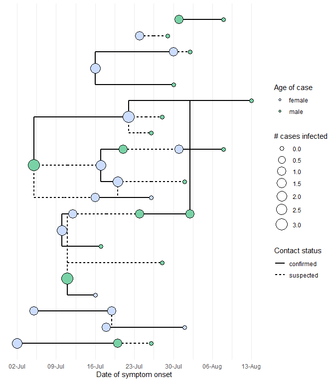

```r
sim_3$directed <- FALSE
plot(
  sim_3,
  method = 'ggplot',
  x_axis = 'onset',
  network_shape = 'rectangle',
  root_order = 'onset',
  node_order = 'subtree_size',
  reverse_node_order = FALSE,
  reverse_root_order = TRUE,
  node_color = 'sex',
  node_size = 'R_i',
  size_range = c(3, 8),
  edge_linetype = 'status',
  position_dodge = FALSE
) +
  labs(
    x = "Date of symptom onset",
    fill = 'Age of case',
    size = "# cases infected",
    linetype = "Contact status"
  ) +
  scale_x_date(
    breaks = "1 week",
    date_labels = "%d-%b"
  )
```